# Intesity of m6A-Tracer around Ki67-marked nucleoli

Tom van Schaik

10 June, 2021

### Introduction

The goal of this analysis is to determine the enrichment of m6A-Tracer signal around nucleoli (marked by Ki67), following Ki67 pA-DamID. Dam-only signal is the control.

### Setup

Load the required libraries.

```r
# Load libraries
library(ggplot2)
library(tidyverse)
library(ggbeeswarm)
library(pixmap)

# Input data
results_dir <- c("../ts201008_E1304_E1321_confocal_various/ts201008_pADamID_m6ATracer_analysis/",
                 "../ts201102_E1349_confocal_synchronization/ts201102_RPE_m6ATracer/ts201102_RPE_timecourse_analysis/",
                 "../ts210308_E1499_confocal/ts210316_RPE_m6ATracer/ts210308_RPE_m6ATracer_analysis/")
                 #"../ts210402_E1546_confocal_Ki67_antibodies/ts210402_HCT116_wt_pADamID_Ki67_antibodies/ts210402_HCT116_wt_pADamID_Ki67_antibodies_analysis/")

# Prepare output directory
output_dir <- "ts210609_nucleolar_enrichment_cell_types"
dir.create(output_dir, showWarnings = FALSE)

# Prepare output files
```

```r
library(knitr)
opts_chunk$set(dev=c('png', 'pdf'), fig.path = file.path(output_dir, "figures/"),
               cache = T)
pdf.options(useDingbats = FALSE)
```

```r
ReadPGN <- function(file.name) {

  # Get image, only grey values
  suppressWarnings(read.pnm(file.name)@grey*255)

}
```

### Strategy

The main problem is substantial difference in microscopy slide quality between the replicates / cell types. This results in consistent results, but also in qualitative variation. I will explore a bit whether I can solve this, but otherwise I can always just “explain” this in the text. Solving means tweaking the parameters to segment nucleoli, mostly.

### 1) Prepare metadata

List the different samples.

```r
metadata <- tibble(cell_statistics = dir(results_dir, recursive = T,
                                         full.names = T,
                                         pattern = "cells_statistics")) %>%
  mutate(sample = str_remove(basename(cell_statistics),
                             "_cells_.*"),
         sample = str_remove(sample, "r._"),
         sample = str_replace(sample, "unsync", "RPE")) %>%
  filter(! grepl("Act", sample) &
           ! grepl("Preview", sample) &
           ! grepl("t\\d+h+_", sample) &
           ! grepl("NOV|HPA", sample)) %>%
  mutate(replicate = case_when(grepl("r1_", cell_statistics) ~ "r2",
                               grepl("r2_", cell_statistics) ~ "r3",
                               T ~ "r1"),
         replicate = factor(replicate, levels = c("r1", "r2", "r3")),
         cell = case_when(grepl("HCT116", sample) ~ "HCT116",
                          grepl("K562", sample) ~ "K562",
                          T ~ "RPE"),
         cell = factor(cell, levels = c("RPE", "HCT116", "K562")),
         condition = case_when(grepl("DMSO", cell_statistics) ~ "DMSO",
                               T ~ "wt"),
         target = ifelse(grepl("Ki67", sample), "Ki67", "Dam"),
         target = factor(target, levels = c("Dam", "Ki67")),
         slide = str_remove(sample, ".*_")) %>%
  mutate(sample = paste(cell, target, condition, replicate, slide, sep = "_")) %>%
  mutate(objects = str_replace(cell_statistics,
                               "cells_statistics.csv",
                               "dapi_segment.pgm"),
         nucleolus_internal = str_replace(objects,
                                          "dapi_segment",
                                          "nucleolus_internal"),
         nucleolus_external = str_replace(objects,
                                          "dapi_segment",
                                          "nucleolus_external"),
         nucleolus = str_replace(objects,
                                 "dapi_segment",
                                 "nucleolus_smooth"),
         tracer = str_replace(objects,
                              "dapi_segment",
                              "m6ATracer_smooth")) %>%
  arrange(cell, target, condition, replicate, slide)

# Print metadata
metadata %>%
  print(n = Inf)
```

```
## # A tibble: 73 x 12
##    cell_statistics sample replicate cell  condition target slide objects
##    <chr>           <chr>  <fct>     <fct> <chr>     <fct>  <chr> <chr>
##  1 ../ts201102_E1… RPE_D… r1        RPE   wt        Dam    002   ../ts2…
##  2 ../ts201102_E1… RPE_D… r1        RPE   wt        Dam    004   ../ts2…
##  3 ../ts201102_E1… RPE_D… r1        RPE   wt        Dam    006   ../ts2…
##  4 ../ts201102_E1… RPE_D… r1        RPE   wt        Dam    009   ../ts2…
##  5 ../ts201102_E1… RPE_D… r1        RPE   wt        Dam    011   ../ts2…
##  6 ../ts201102_E1… RPE_D… r1        RPE   wt        Dam    013   ../ts2…
##  7 ../ts201102_E1… RPE_D… r1        RPE   wt        Dam    015   ../ts2…
##  8 ../ts201102_E1… RPE_D… r1        RPE   wt        Dam    017   ../ts2…
##  9 ../ts201102_E1… RPE_D… r1        RPE   wt        Dam    019   ../ts2…
## 10 ../ts210308_E1… RPE_D… r2        RPE   wt        Dam    004   ../ts2…
## 11 ../ts210308_E1… RPE_D… r2        RPE   wt        Dam    007   ../ts2…
## 12 ../ts210308_E1… RPE_D… r2        RPE   wt        Dam    009   ../ts2…
```

[output cut: 63 more lines]

### 2) Load cell sizes and create a cell table

Load the cells and show the sizes. Possibly filter on those.

```r
# Load all cells
LoadCells <- function(i) {
  tib <- read_csv(metadata$cell_statistics[i]) %>%
    dplyr::select(c(1:2)) %>%
    rename_all(~c("volume", "surface")) %>%
    add_column(object = 1:nrow(.),
               sample = metadata$sample[i],
               replicate = metadata$replicate[i],
               cell = metadata$cell[i],
               condition = metadata$condition[i],
               target = metadata$target[i],
               slide = metadata$slide[i]) %>%
    mutate(cell_id = paste(sample, object, sep = "_"))

  tib

}

tib_cells <- lapply(1:nrow(metadata), LoadCells) %>%
  purrr::reduce(bind_rows)
```

Plot and filter these cells.

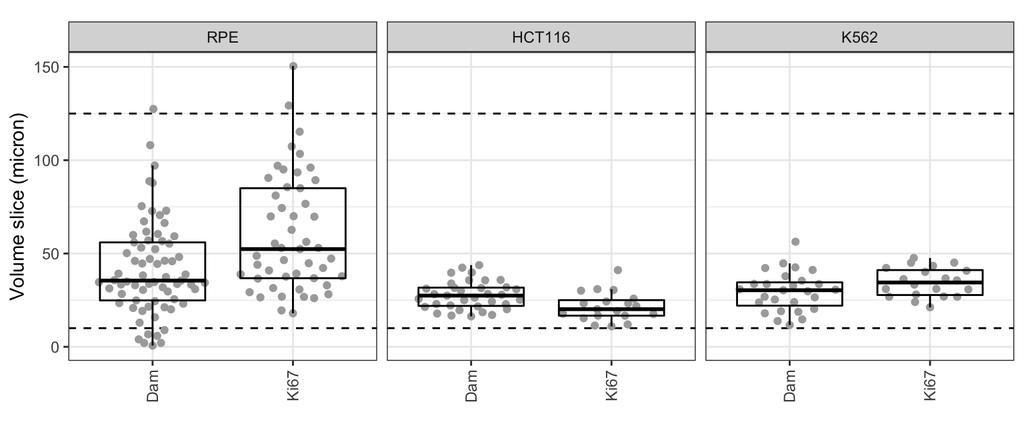

```r
# Set size limits
limits_size <- c(10, 125)

# Plot cell volume
tib_cells %>%
  ggplot(aes(x = target, y = volume)) +
  geom_hline(yintercept = 0, alpha = 0) +
  geom_hline(yintercept = limits_size, col = "black", linetype = "dashed") +
  geom_quasirandom(col = "darkgrey") +
  geom_boxplot(fill = NA, col = "black", outlier.shape = NA) +
  facet_grid(. ~ cell) +
  xlab("") +
  ylab("Volume slice (micron)") +
  theme_bw() +
  theme(aspect.ratio = 1,
        axis.text.x = element_text(angle = 90, vjust = 0.5, hjust=1))
```

```r
# Filter cells for cutoff
tib_cells <- tib_cells %>%
  mutate(size_filter = volume >= limits_size[1] &
           volume <= limits_size[2])
```

### 3) Load the pgm maps

Load the .pgm files for the various channels.

```r
# Load all cells
LoadPGMMaps <- function(i, n_min = 5) {

  # Load objects
  objects <- ReadPGN(metadata$objects[i])
  nucleolus <- ReadPGN(metadata$nucleolus[i])
  nucleolus_internal <- ReadPGN(metadata$nucleolus_internal[i])
  nucleolus_external <- ReadPGN(metadata$nucleolus_external[i])
  tracer <- ReadPGN(metadata$tracer[i])

  tib <- tibble(object = c(objects),
                nucleolus_internal = c(nucleolus_internal),
                nucleolus_external = c(nucleolus_external),
                nucleolus = c(nucleolus),
                tracer = c(tracer)) %>%
    filter(object != 0) %>%
    rowwise() %>%
    mutate(nucleolus_internal = min(nucleolus_internal, 254),
           nucleolus_external = min(nucleolus_external, 254)) %>%
    ungroup() %>%
    group_by(object, nucleolus_internal, nucleolus_external) %>%
    summarise(n = n(),
              tracer = mean(tracer),
              nucleolus = mean(nucleolus)) %>%
    ungroup() %>%
    group_by(object) %>%
    mutate(tracer_enrichment = log2(tracer / weighted.mean(tracer, n)),
           nucleolus_enrichment = log2(nucleolus / weighted.mean(nucleolus, n))) %>%
    ungroup() %>%
    filter(n > n_min) %>%
    mutate(distance = nucleolus_external - nucleolus_internal) %>%
    arrange(object, distance) %>%
    add_column(sample = metadata$sample[i],
               replicate = metadata$replicate[i],
               cell = metadata$cell[i],
               condition = metadata$condition[i],
               target = metadata$target[i],
               slide = metadata$slide[i]) %>%
    mutate(cell_id = paste(sample, object, sep = "_"))

  tib

}

tib_intensities <- lapply(1:nrow(metadata), LoadPGMMaps) %>%
  purrr::reduce(bind_rows)

# Filter out cells that did not pass the cell size filter
tib_intensities <- tib_intensities %>%
  dplyr::filter(cell_id %in% (tib_cells %>%
                                filter(size_filter == T) %>%
                                pull(cell_id)))
```

Plots.

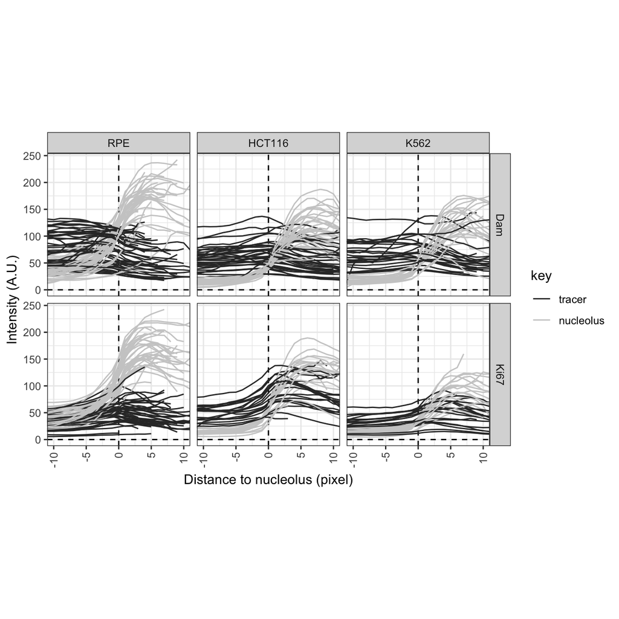

```r
# Filter very bad cells
# - only positive / negative scores
# - extreme values
remove_samples <- tib_intensities %>%
  gather(key, value, nucleolus_enrichment, tracer_enrichment) %>%
  mutate(key = str_remove(key, "_enrichment")) %>%
  filter(distance > -11 & distance <= 11) %>%
  group_by(key, target, cell, cell_id) %>%
  dplyr::summarise(q1 = quantile(value, 0.1),
                   q5 = quantile(value, 0.5),
                   q9 = quantile(value, 0.9)) %>%
  filter(q1 > 0.5 | q9 < 0 | q1 < -2.5 | q9 > 3) %>%
  pull(cell_id)


# Plot intensity per cell
tib_gather <- tib_intensities %>%
  filter(! cell_id %in% remove_samples) %>%
  gather(key, value, nucleolus, tracer) %>%
  filter(distance > -14 & distance <= 14) %>%
  mutate(key = factor(key, levels = c("tracer", "nucleolus")))

tib_gather %>%
  ggplot(aes(x = distance, y = value, col = key,
             group = interaction(key, cell_id, condition))) +
  geom_hline(yintercept = 0, col = "black", linetype = "dashed") +
  geom_vline(xintercept = 0, col = "black", linetype = "dashed") +
  geom_line() +
  facet_grid(target ~ cell, scales = "free_y") +
  xlab("Distance to nucleolus (pixel)") +
  ylab("Intensity (A.U.)") +
  coord_cartesian(xlim = c(-10, 10)) +
  scale_color_grey() +
  theme_bw() +
  theme(aspect.ratio = 1,
        axis.text.x = element_text(angle = 90, vjust = 0.5, hjust=1))
```

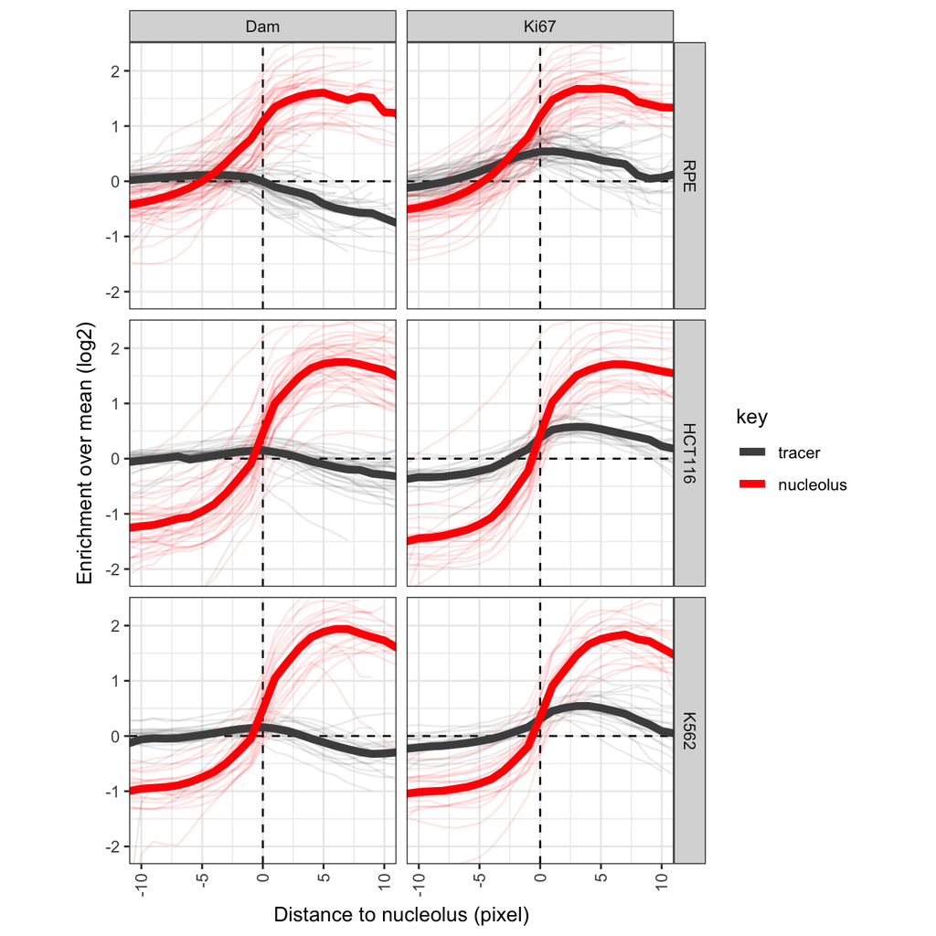

```r
# Plot intensity per cell - for enrichments
tib_gather <- tib_intensities %>%
  filter(! cell_id %in% remove_samples) %>%
  gather(key, value, nucleolus_enrichment, tracer_enrichment) %>%
  filter(distance > -14 & distance <= 14) %>%
  mutate(key = str_remove(key, "_enrichment")) %>%
  mutate(key = factor(key, levels = c("tracer", "nucleolus")))

tib_gather %>%
  ggplot(aes(x = distance, y = value, col = key,
             fill = target, group = interaction(key, cell_id, condition))) +
  geom_hline(yintercept = 0, col = "black", linetype = "dashed") +
  geom_vline(xintercept = 0, col = "black", linetype = "dashed") +
  geom_line(alpha = 0.1) +
  stat_summary(fun = mean, aes(group = key),
               geom = "line", size = 2) +
  facet_grid(cell ~ target, scales = "free_y") +
  xlab("Distance to nucleolus (pixel)") +
  ylab("Enrichment over mean (log2)") +
  coord_cartesian(xlim = c(-10, 10),
                  ylim = c(-2.1, 2.3)) +
  scale_color_manual(values = c("grey30", "red")) +
  theme_bw() +
  theme(aspect.ratio = 1,
        axis.text.x = element_text(angle = 90, vjust = 0.5, hjust=1))
```

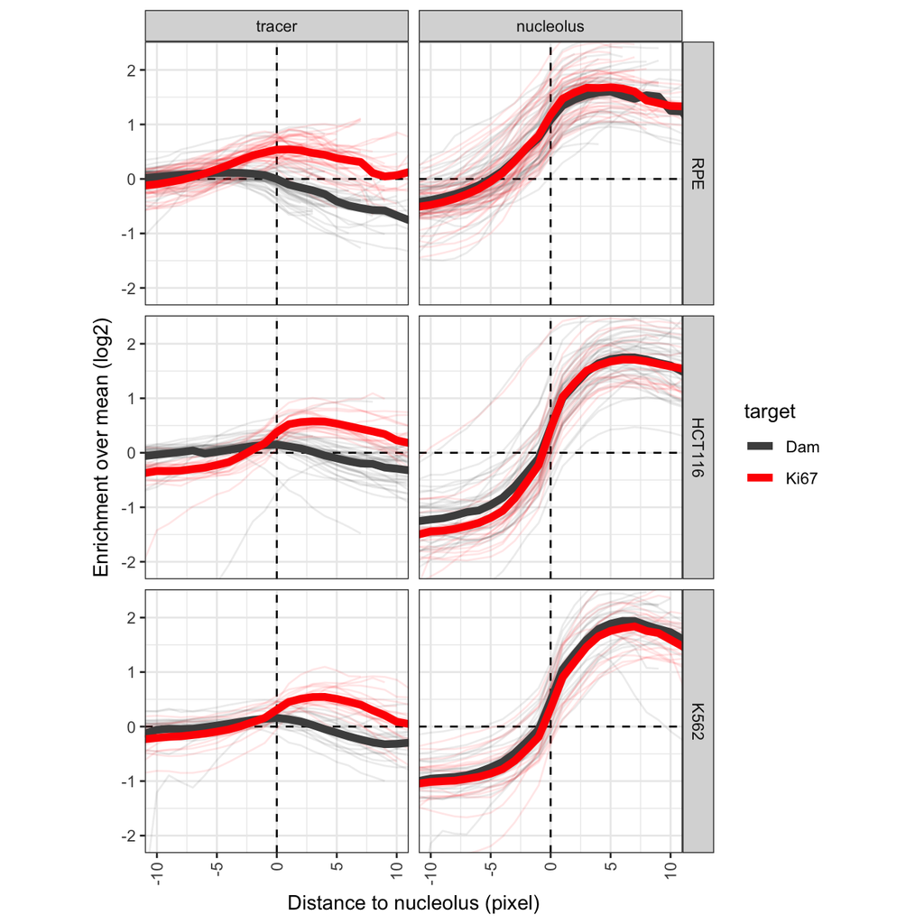

```r
tib_gather %>%
  ggplot(aes(x = distance, y = value, col = target,
             fill = target,
             group = interaction(target, cell_id, condition))) +
  geom_hline(yintercept = 0, col = "black", linetype = "dashed") +
  geom_vline(xintercept = 0, col = "black", linetype = "dashed") +
  geom_line(alpha = 0.1) +
  stat_summary(fun = mean, aes(group = target),
               geom = "line", size = 2) +
  # stat_summary(fun.data = mean_se, geom = "ribbon", aes(group = target),
  #              fun.args = list(mult = 1.96), col = NA, alpha = 0.2) +
  facet_grid(cell ~ key, scales = "free_y") +
  xlab("Distance to nucleolus (pixel)") +
  ylab("Enrichment over mean (log2)") +
  coord_cartesian(xlim = c(-10, 10),
                  ylim = c(-2.1, 2.3)) +
  scale_color_manual(values = c("grey30", "red")) +
  scale_fill_manual(values = c("grey30", "red")) +
  theme_bw() +
  theme(aspect.ratio = 1,
        axis.text.x = element_text(angle = 90, vjust = 0.5, hjust=1))
```

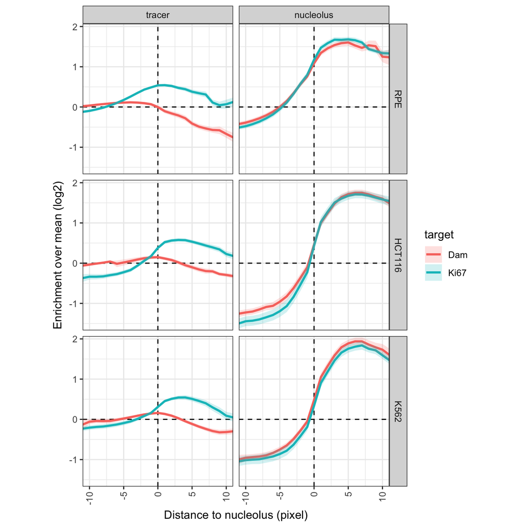

```r
# Means only
# 1) Combined
tib_gather %>%
  ggplot(aes(x = distance, y = value, col = target,
             fill = target, group = target)) +
  geom_hline(yintercept = 0, col = "black", linetype = "dashed") +
  geom_vline(xintercept = 0, col = "black", linetype = "dashed") +
  stat_summary(fun = mean, geom = "line", size = 1) +
  # stat_summary(fun.data = mean_se, geom = "errorbar",
  #              col = "darkgrey", linetype = "solid") +
  stat_summary(fun.data = mean_se, geom = "ribbon",
               col = NA, alpha = 0.2) +
  facet_grid(cell ~ key) +
  xlab("Distance to nucleolus (pixel)") +
  ylab("Enrichment over mean (log2)") +
  coord_cartesian(xlim = c(-10, 10),
                  ylim = c(-1.5, 1.9)) +
  #scale_color_grey() +
  theme_bw() +
  theme(aspect.ratio = 1,
        axis.text.x = element_text(angle = 90, vjust = 0.5, hjust=1))
```

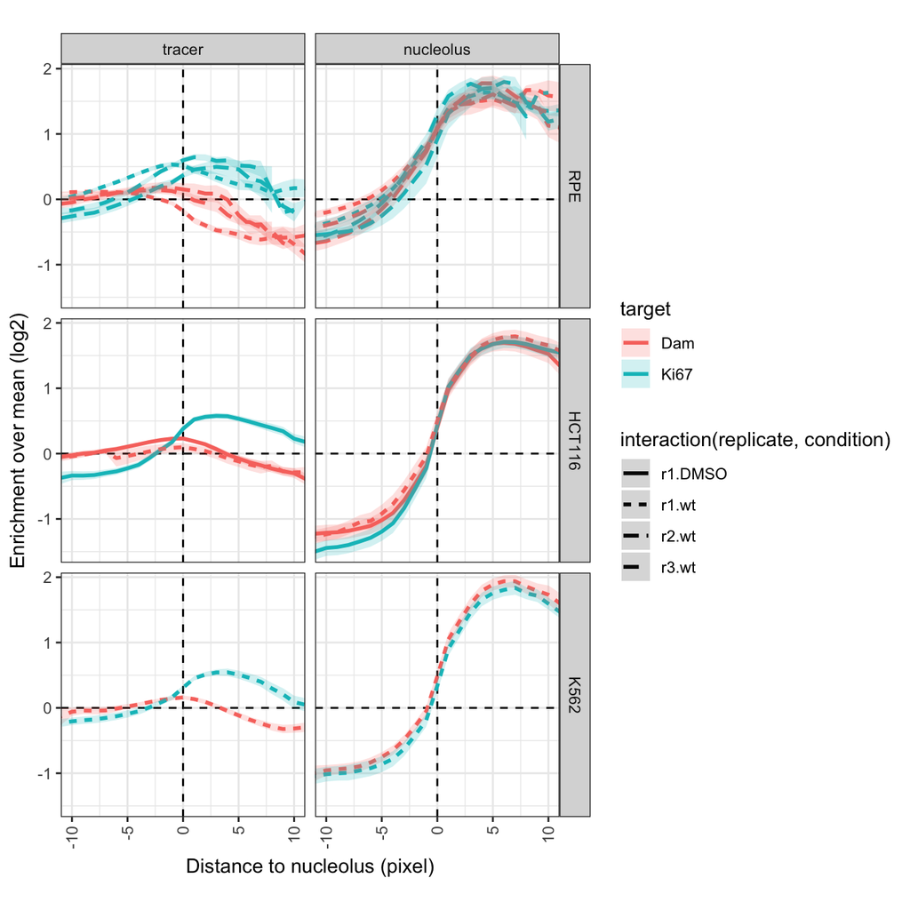

```r
# 2) Per replicate
tib_gather %>%
  ggplot(aes(x = distance, y = value, col = target, linetype = interaction(replicate, condition),
             fill = target, group = interaction(target, replicate, condition))) +
  geom_hline(yintercept = 0, col = "black", linetype = "dashed") +
  geom_vline(xintercept = 0, col = "black", linetype = "dashed") +
  stat_summary(fun = mean, geom = "line", size = 1) +
  # stat_summary(fun.data = mean_se, geom = "errorbar",
  #              col = "darkgrey", linetype = "solid") +
  stat_summary(fun.data = mean_se, geom = "ribbon",
               col = NA, alpha = 0.2) +
  facet_grid(cell ~ key) +
  xlab("Distance to nucleolus (pixel)") +
  ylab("Enrichment over mean (log2)") +
  coord_cartesian(xlim = c(-10, 10),
                  ylim = c(-1.5, 1.9)) +
  #scale_color_grey() +
  theme_bw() +
  theme(aspect.ratio = 1,
        axis.text.x = element_text(angle = 90, vjust = 0.5, hjust=1))
```

### Conclusion

Several observations:

- Ki67 m6A-Tracer is enriched near Ki67 protein. That’s good.
- This enrichment is almost equal between HCT116 and K562 cells. RPE cells are different, probably due to a difference in slide quality. At least, the nucleolus difference is also less pronounced at nucleolar borders.

Overall, this is a positive result.